# ARIMA modeling

Maurício Collaça

11 de agosto de 2018

# 1 Time Series Regression Models

Regression: $Y_i = \beta X_i + \epsilon_i$ where $\epsilon_i$ is **white noise**

## 1.1 White Noise (WN)

- independent normals with common variance
- is basic building block of time series

## 1.2 AutoRegression (AR)

$X_t = \phi X_{t-1} + \epsilon_t$ ($\epsilon_t$ is **white noise**)

Tipically time series data are correlated and assuming error are not correlated may lead to a bad forecast. One way to overcome this problems is to use a Moving Average for the errors.

## 1.3 Moving Average (MA)

$\epsilon_t = W_t + \theta W_{t-1}%$ ($W_t$ is **white noise**)

Errors $\epsilon_t$ at time t are correlated to the errors $\epsilon_{t-1}$ at time t-1 because the both have a “$W_{t-1}$”

## 1.4 Autoregressive + Moving Average (ARMA)

$X_t = \phi X_{t-1} + W_t + \theta W_{t-1}$

Putting these two together is a model with autocorrelation and autocorrelated errors.

# 2 Stationarity and Nonstationarity

In the context of time series, it is stationary when it is “stable”, meaning:

- the mean is constant over time (no trend)
- the correlation structure remains constant over time

Stationarity means we can use simple averaging to estimate $\bar X$ correlation.

Pairs can be used to estimate correlation on different lags: (x1,x2)(x2,x3)… for lag 1.

This works because relation between contiguous values of the series remains the same overtime.

Similarly (x1,x3)(x2,x4)… for lag 2.

Stationary example: Southern Oscillation Index

Reasonable to assume stationary, but perhaps some slight trend.

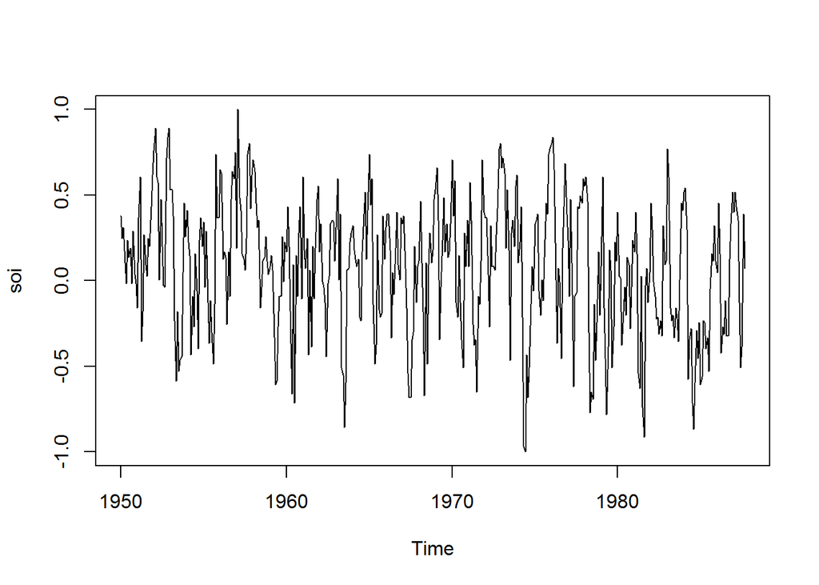

```r
library(astsa)
plot(soi)
```

Scatter plots show correlation in terms of lag.

To estimate autocorrelation, compute the correlation coefficient between the time series and itself at various lags.

Correlation at lag 1 (e.g. positive) and lag 6 (e.g. negative). In this case 6 periods are months where correlation changes between summer and winter.

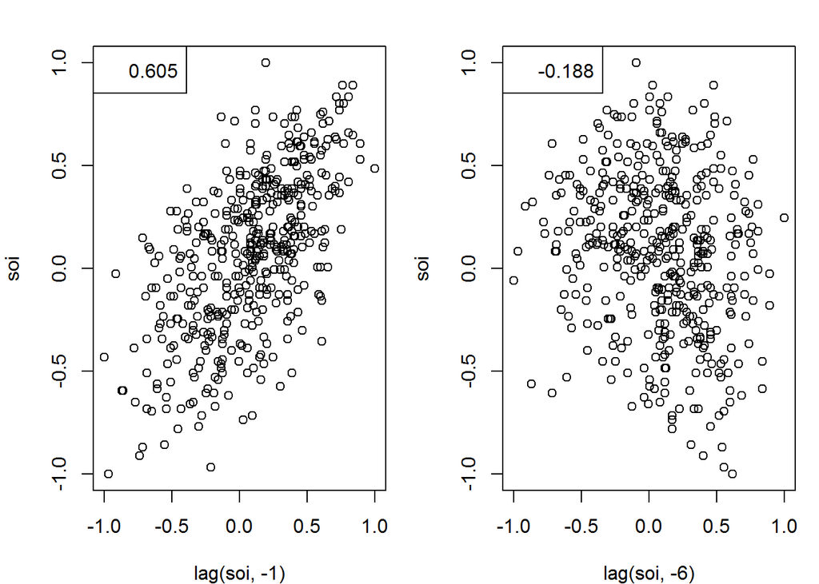

```r
par(mfrow=1:2, mar=c(4,4,2,1))
plot(lag(soi,-1), soi)
legend("topleft",legend=round(cor(soi[-1], soi[-length(soi)]),3))
plot(lag(soi,-6), soi)
legend("topleft", legend=round(cor(soi[-(1:6)], soi[-((length(soi)-5):length(soi))]),3))
```

# 3 Random Walk Trend

The global temperature deviation is an example of Random Walk (not stationary) but its differenced data is stationary.

```r
plot(cbind(globtemp, diff(globtemp)), main="Global mean land-ocean temperature deviations")
```

[output not shown]

# 4 Trend Stationary

Stationarity around a trend, differencing still works.

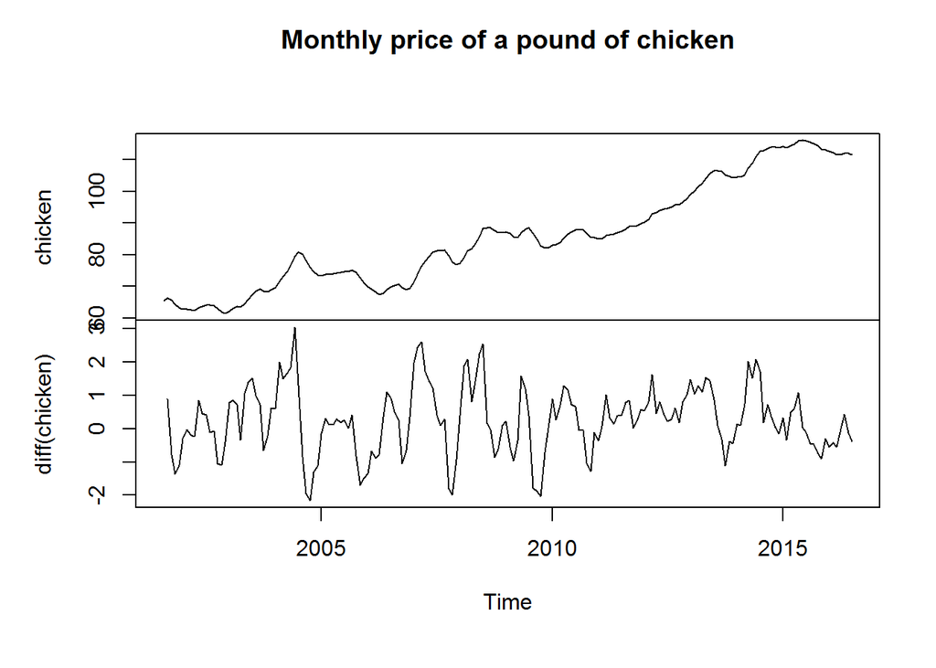

```r
plot(cbind(chicken, diff(chicken)), main="Monthly price of a pound of chicken")
```

# 5 Nonstationarity in trend and variability

First log can stabilize the variance, then difference can detrend.

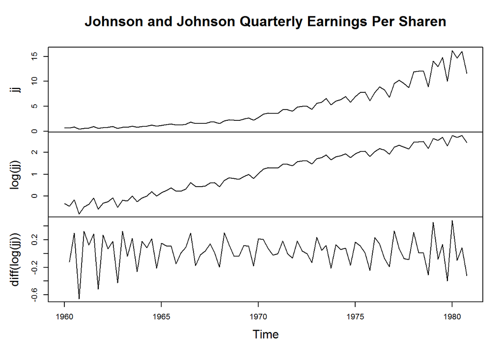

```r
plot(cbind(jj, log(jj), diff(log(jj))), main="Johnson and Johnson Quarterly Earnings Per Sharen")
```

Often time series are generated as $X_t=(1+p_t)X_{t−1}$ meaning that the value of the time series observed at time $t$ equals the value observed at time $t−1$ and a small percent change $pt$ at time $t$.

A simple deterministic example is putting money into a bank with a fixed interest $p$. In this case, $X_t$ is the value of the account at time period $t$ with an initial deposit of $X_0$.

Typically, $p_t$ is referred to as the return or growth rate of a time series, and this process is often stable.

For reasons that are outside the scope of this course, it can be shown that the growth rate $p_t$ can be approximated by $Y_t=log(X_t)−log(X_{t−1})\approx p_t$.

# 6 Stationary Time Series: ARMA

Why to use ARMA models for stationary time series data?

Wold Decomposition

Wold proved that any stationary time series may be represented as a linear combination of white noise:

$$X_t = W_t + a_1 W_{t-1} + a_2 W_{t-2} + ...$$
For constants $a_1, a_2, ...$

Any ARMA model has this form, which means they are suited to modeling time series.

Note: Special case of MA($q$) is already of this form, where constants are $0$ after $q$-th term.

# 7 Generating ARMA using arima.sim()

```
arima.sim(model, n, ...)
```

- model is a list with order of the model as c(p, d, q) and the coefficients
  - p is the order of the AR
  - q is the order of the MA
- n is the length of the series

## 7.1 MA(1)

Recall
$$X_t = W_t + \theta W_{t-1}%$$
Given $\theta=0.9$
$$X_t = W_t + 0.9W_{t-1}$$

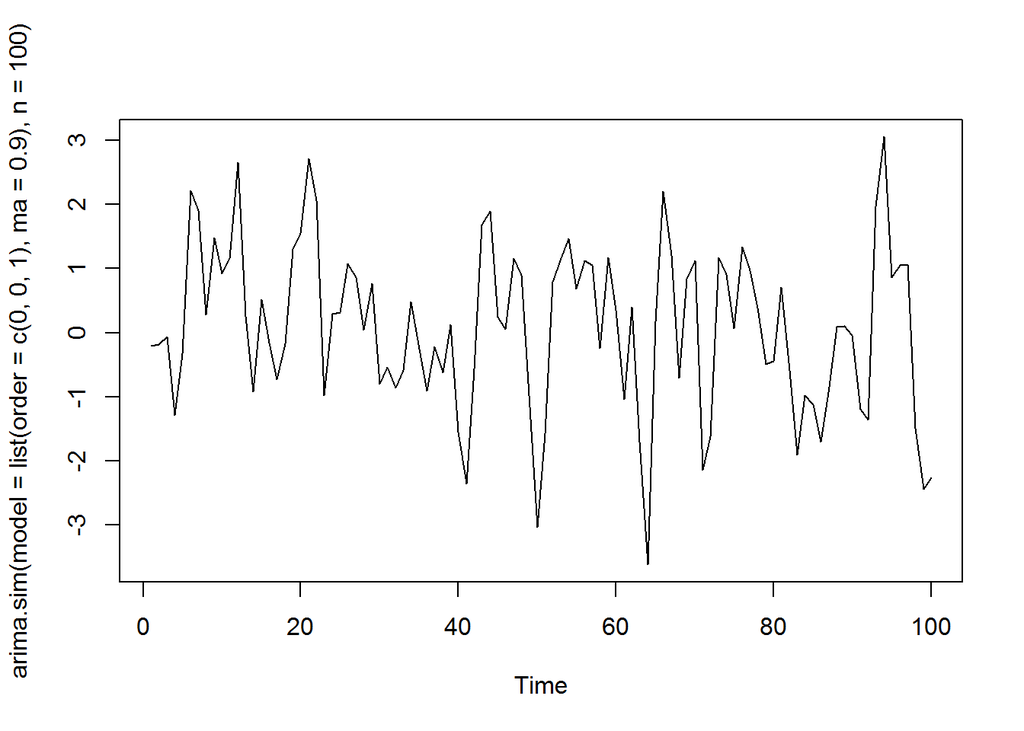

```r
plot(arima.sim(model=list(order=c(0,0,1), ma=0.9), n=100))
```

## 7.2 AR(2)

Recall
$$X_t = \phi X_{t-2} + W_t$$
Given $\phi=-0.9$
$$X_t =-0.9 X_{t-2} + W_t$$

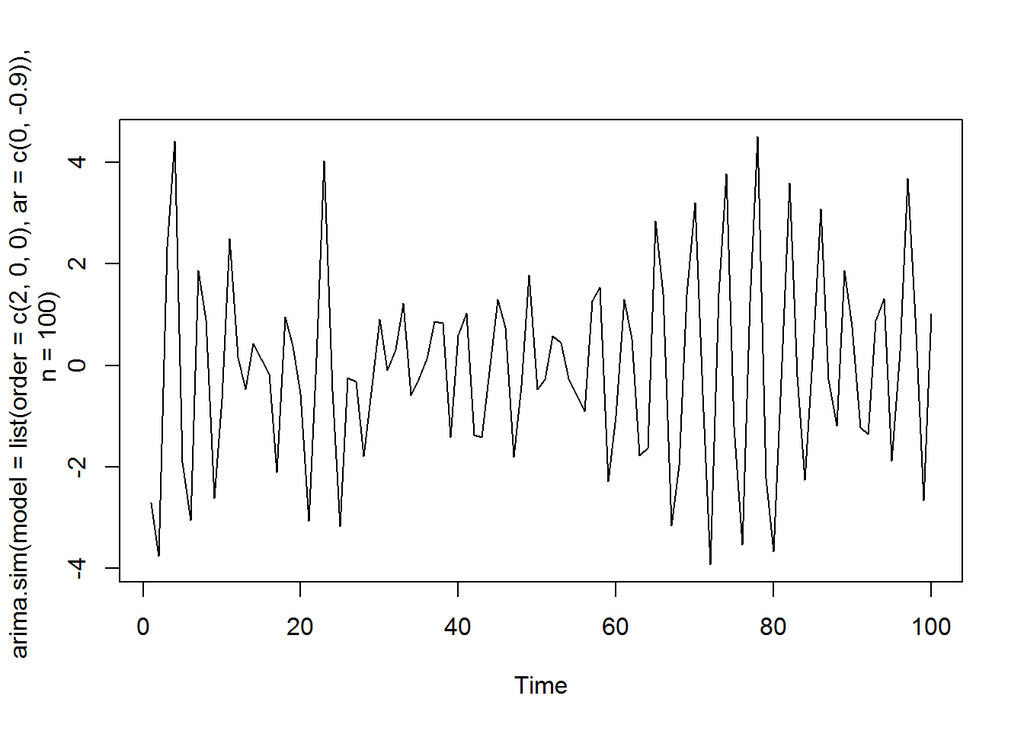

```r
plot(arima.sim(model=list(order=c(2,0,0), ar=c(0,-0.9)), n=100))
```

Notice the data are somewhat cyclic.

Generating and plotting WN

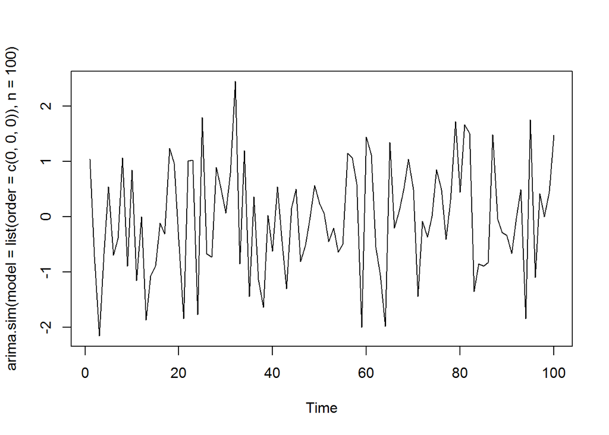

```r
plot(arima.sim(model = list(order=c(0,0,0)), n=100))
```

# 8 AR and MA Models

You can’t identify a model simply looking at the data:

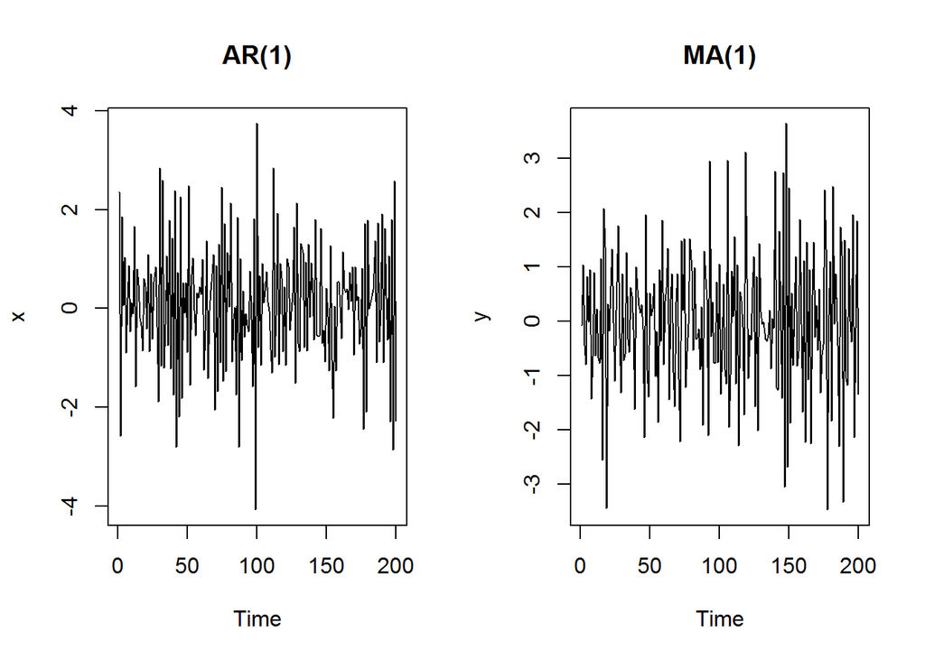

```r
x <- arima.sim(list(order = c(1, 0, 0), ar = -.7), n = 200)
y <- arima.sim(list(order = c(0, 0, 1), ma = -.7), n = 200)
par(mfrow = c(1, 2))
plot(x, main = "AR(1)")
plot(y, main = "MA(1)")
```

## 8.1 ACF and PACF identify Model’s orders

Autocorrelation Function and Partial Autocorrelation Function.

| function | AR(p) | MA(q) | ARMA(p, q) |
| --- | --- | --- | --- |
| ACF | Tails off | Cut off lag q | Tails off |
| PACF | Cuts off lag p | Tails off | Tails off |

### 8.1.1 AR(2) ACF/PACF

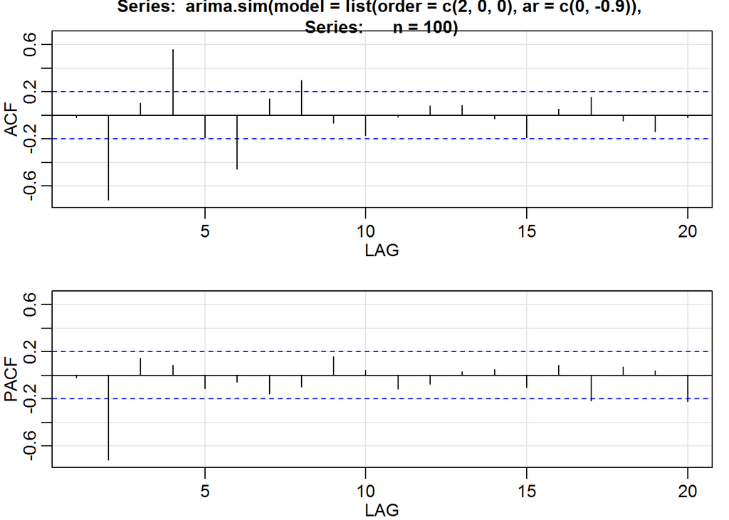

```r
par(mfrow=c(1,2))
invisible(acf2(arima.sim(model=list(order=c(2,0,0), ar=c(0,-0.9)), n=100)))
```

### 8.1.2 MA(1)) ACF/PACF

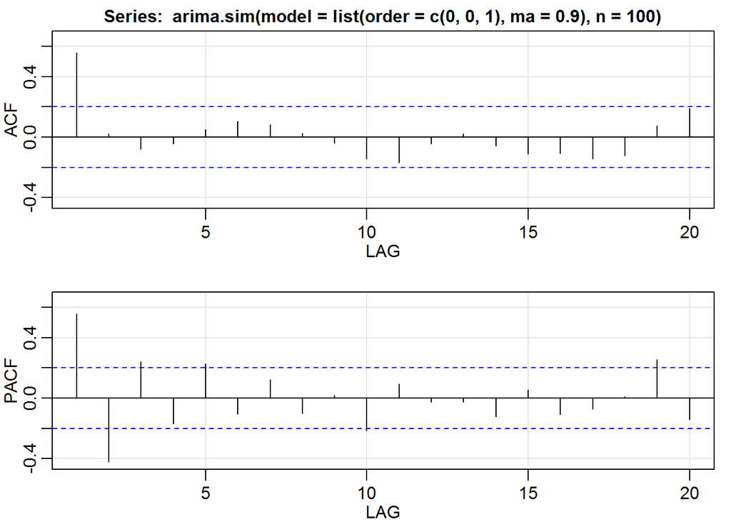

```r
par(mfrow=c(1,2))
invisible(acf2(arima.sim(model=list(order=c(0,0,1), ma=0.9), n=100)))
```

# 9 Estimation

- Estimation for time series is similar to using least squares for regression
  - For time series it’s much harder and the results are not explicity.
- Estimates are obtained numerically using ideas of Gauss and Newton

## 9.1 Estimation with astsa::sarima

### 9.1.1 AR(2) with mean 50

$$(Today − Mean) = Slope \times (Y esterday − Mean) + Noise$$
$$X_t = 50 + 1.5(X_{t-1} - 50) - .75(X_{t-2} -50) + W_t$$

```r
x <- arima.sim(list(order = c(2,0,0), ar = c(1.5,-.75)), n=200) + 50
x_fit <- sarima(x, p=2, d=0, q=0, details=FALSE)
x_fit$ttable
```

```
      Estimate     SE  t.value p.value
ar1     1.5064 0.0400  37.6174       0
ar2    -0.8120 0.0398 -20.3937       0
xmean  49.9523 0.2291 218.0614       0
```

As expected, ACF tails off and PACF cuts off lag 2: AR(2)

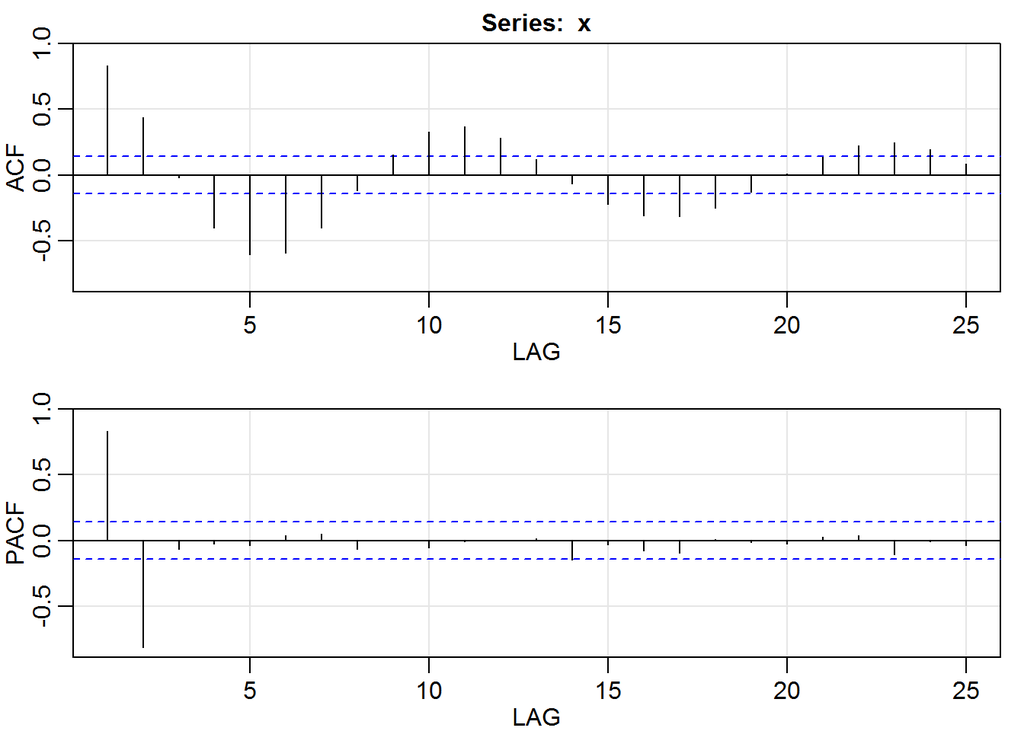

```r
invisible(acf2(x))
```

### 9.1.2 MA(1) with mean 0

```r
y <- arima.sim(list(order = c(0,0,1), ma=-.7), n=200)
y_fit <- sarima(y, p=0, d=0, q=1, details=FALSE)
y_fit$ttable
```

```
      Estimate     SE  t.value p.value
ma1    -0.6649 0.0464 -14.3201  0.0000
xmean  -0.0213 0.0237  -0.8973  0.3706
```

As expected, ACF cuts off lag 1 and PACF tails off: MA(1)

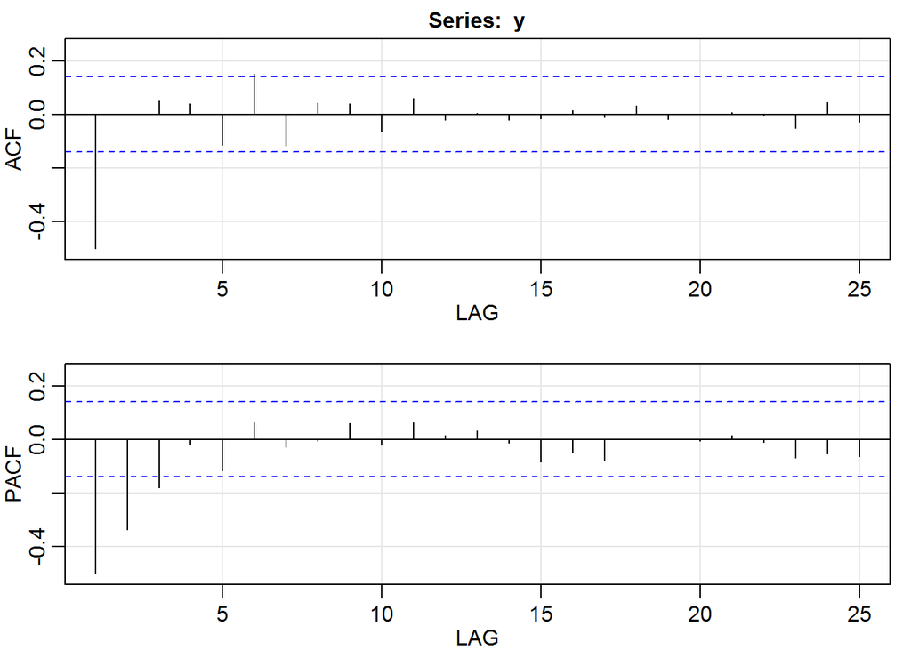

```r
invisible(acf2(y))
```

# 10 AR and MA together

Autocorrelation and autocorrelated errors

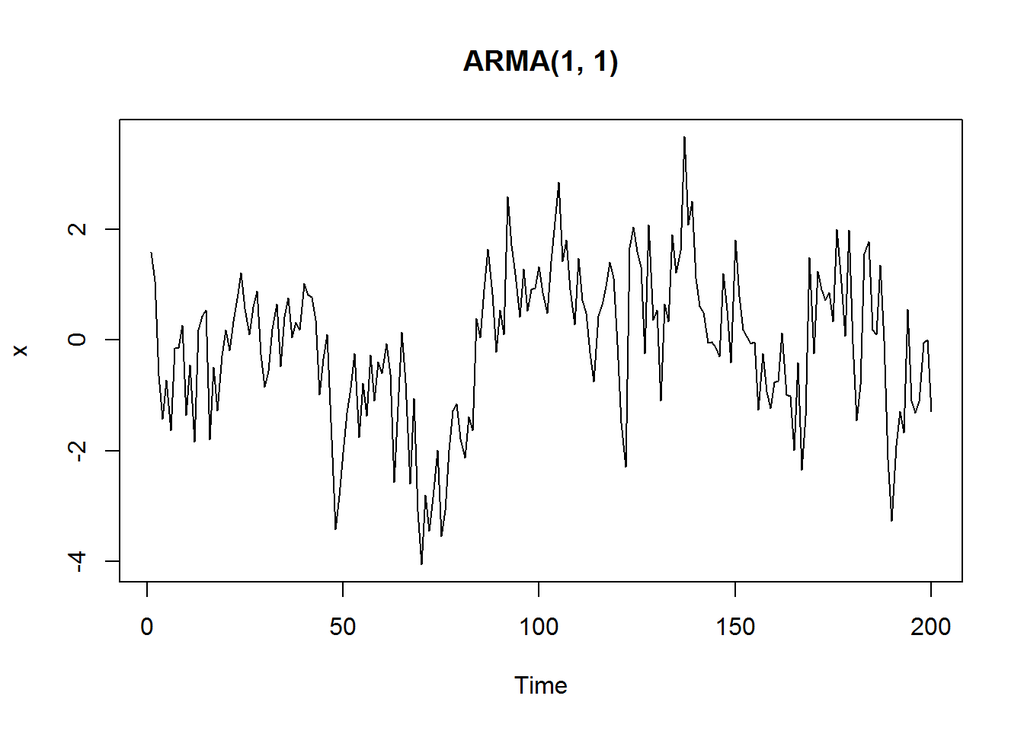

```r
x <- arima.sim(list(order = c(1,0,1), ar=.9, ma=-.4), n=200)
plot(x, main = "ARMA(1, 1)")
```

For an ARMA model both ACF/PACF tail off:

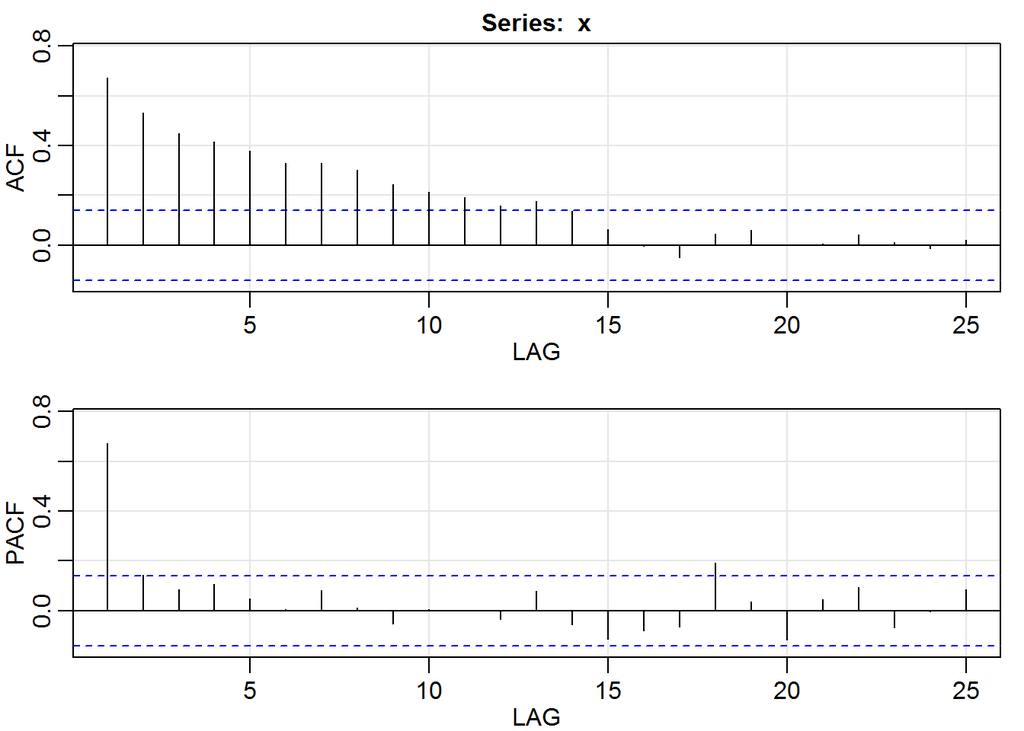

```r
invisible(acf2(x))
```

Estimation from an ARMA(1,1) model with mean 50

```r
x <- arima.sim(list(order = c(1, 0, 1), ar = .9, ma = -.4 ), n = 200) + 50
x_fit <- sarima(x, p = 1, d = 0, q = 1, details=FALSE)
x_fit$ttable
```

```
      Estimate     SE  t.value p.value
ar1     0.8624 0.0419  20.5822   0e+00
ma1    -0.2681 0.0716  -3.7445   2e-04
xmean  50.1779 0.3555 141.1381   0e+00
```

Estimation from a simulated ARMA(2,1)

$$X_t = X_{t-1} + -.9 X_{t-2} + W_t + .8 W_{t-1}$$

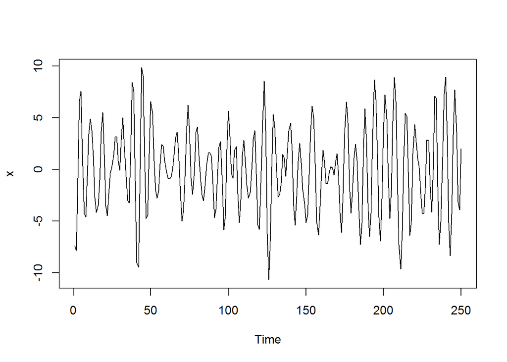

```r
x <- arima.sim(list(order = c(2, 0, 1), ar = c(1, -.9), ma = .8 ), n = 250)
plot(x)
```

```r
x_fit <- sarima(x, p = 2, d = 0, q = 1, details=FALSE)
x_fit$ttable
```

```
      Estimate     SE  t.value p.value
ar1     1.0142 0.0314  32.2609  0.0000
ar2    -0.8771 0.0310 -28.2729  0.0000
ma1     0.8326 0.0342  24.3459  0.0000
xmean   0.0621 0.1417   0.4384  0.6615
```

# 11 Model choice and Residual Analysis

## 11.1 AIC and BIC

It’s often two ore more models seems reasonable. It’s tipically a good idea to fit a few models before deciding on the best one.

AIC and BIC ate the two most popular methods to choose the best model.

As more parameters are include in the model the error gets smaller whether or not the parameters are needed.

- AIC and BIC measure the error and penalize (differently) for adding parameters.
- For example, AIC has $k=2$ and BIC has bigger penalty $k=log(n)$ and tends to choose a model with fewer parameters but the two however often agree.
- Goal: find the model with the smallest AIC or BIC

## 11.2 Model Choice: AR(1) vs. MA(2)

Quarterly U.S. GNP

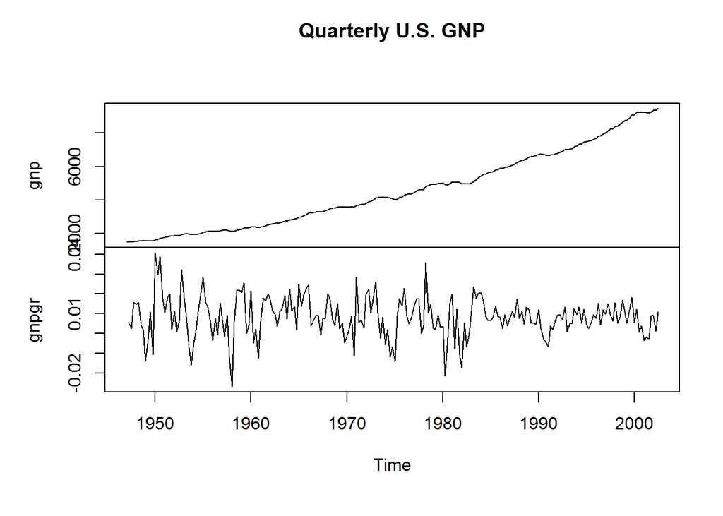

```r
gnpgr <- diff(log(gnp))
plot(cbind(gnp, gnpgr), main="Quarterly U.S. GNP")
```

AR(1)

```r
sarima(gnpgr, p = 1, d = 0, q = 0, details=FALSE)[c("AIC","BIC")]
```

```
$AIC
[1] -8.294403

$BIC
[1] -9.263748
```

MA(2)

```r
sarima(gnpgr, p = 0, d = 0, q = 2, details=FALSE)[c("AIC","BIC")]
```

```
$AIC
[1] -8.297695

$BIC
[1] -9.251712
```

AIC prefers the MA(2) while BIC preferes the AR(1).

Since the AR(1) is a simpler model it’ll be appropriate to prefer that.

# 12 Residual Analsys

The basic of the residual analysis is the same as in the Regression. We want to make sure that residuals are white gaussian noise, otherwise, we haven’t found the best model.

## 12.1 AR(1) fit to the Gross Rate of Quarterly U.S.GNP

Here the residuals are fine.

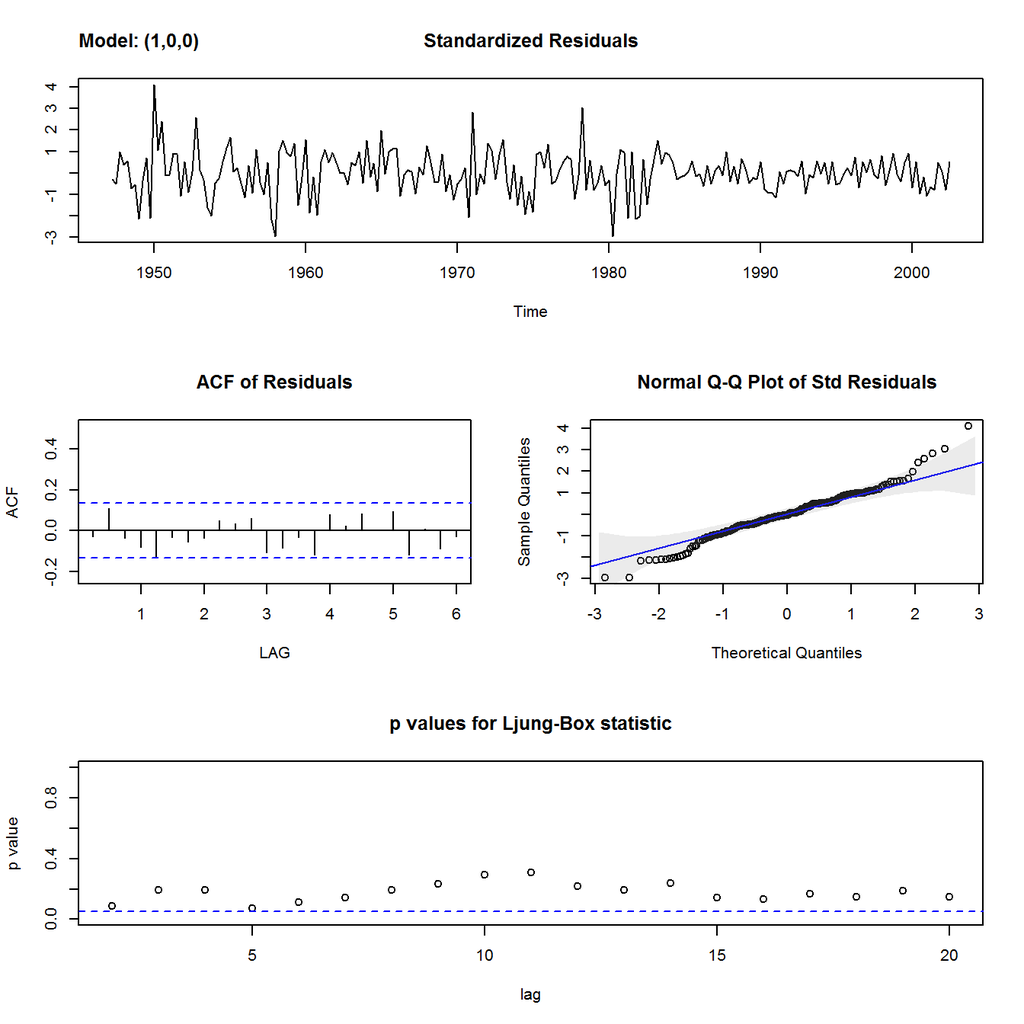

```
$fit

Call:
stats::arima(x = xdata, order = c(p, d, q), seasonal = list(order = c(P, D,
    Q), period = S), xreg = xmean, include.mean = FALSE, optim.control = list(trace = trc,
    REPORT = 1, reltol = tol))

Coefficients:
         ar1   xmean
      0.3467  0.0083
s.e.  0.0627  0.0010

sigma^2 estimated as 9.03e-05:  log likelihood = 718.61,  aic = -1431.22

$degrees_of_freedom
[1] 220

$ttable
      Estimate     SE t.value p.value
ar1     0.3467 0.0627  5.5255       0
xmean   0.0083 0.0010  8.5398       0

$AIC
[1] -8.294403

$AICc
[1] -8.284898

$BIC
[1] -9.263748
```

```r
sarima(gnpgr, p = 1, d = 0, q = 0)
```

## 12.2 Find the best model for Annual Varve log difference Series

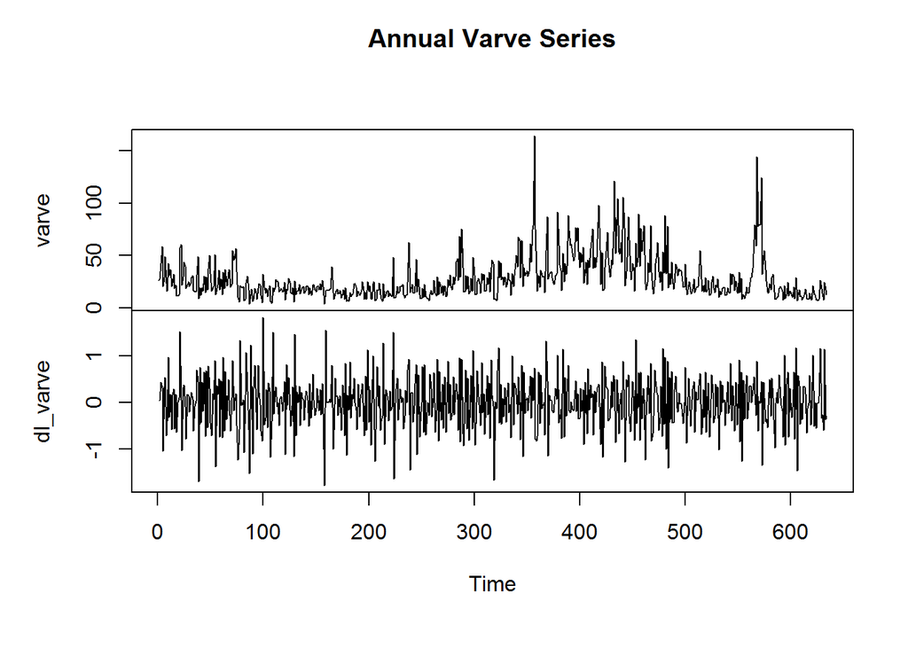

```r
data(varve)
dl_varve <- diff(log(varve))
plot(cbind(varve, dl_varve), main="Annual Varve Series")
```

### 12.2.1 Fitting an MA(1) model

```r
sarima(dl_varve,0,0,1, details=FALSE)[c("AIC", "BIC")]
```

```
$AIC
[1] -0.4406366

$BIC
[1] -1.426575
```

### 12.2.2 Fitting an MA(2) model improved the AIC and BIC over the MA(1) model

```r
sarima(dl_varve,0,0,2, details=FALSE)[c("AIC", "BIC")]
```

```
$AIC
[1] -0.4629629

$BIC
[1] -1.441871
```

### 12.2.3 Fitting an ARMA(1,1) model improved the AIC and BIC over the MA(2) model

```r
sarima(dl_varve,1,0,1, details=FALSE)[c("AIC", "BIC")]
```

```
$AIC
[1] -0.467376

$BIC
[1] -1.446284
```

AIC and BIC help you find the model with the smallest error using the least number of parameters. The idea is based on the parsimony principle, which is basic to all science and tells you to choose the simplest scientific explanation that fits the evidence.

## 12.3 Residual Analysis of models MA(1) and ARMA(1,1) for the Annual Varve log difference Series

### 12.3.1 MA(1) model

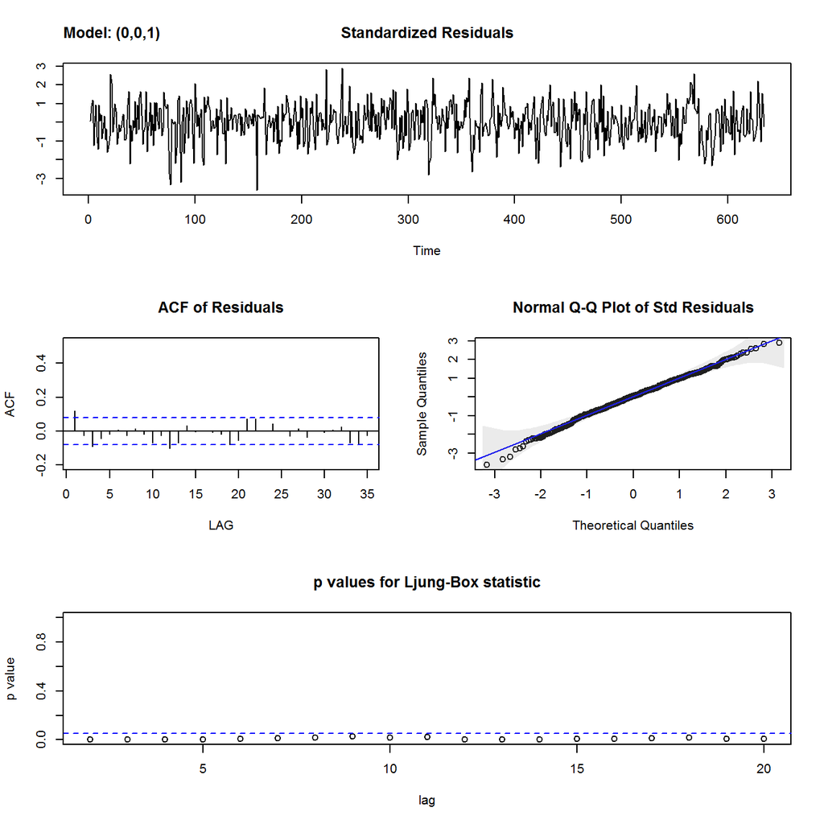

```
$fit

Call:
stats::arima(x = xdata, order = c(p, d, q), seasonal = list(order = c(P, D,
    Q), period = S), xreg = xmean, include.mean = FALSE, optim.control = list(trace = trc,
    REPORT = 1, reltol = tol))

Coefficients:
          ma1    xmean
      -0.7710  -0.0013
s.e.   0.0341   0.0044

sigma^2 estimated as 0.2353:  log likelihood = -440.68,  aic = 887.36

$degrees_of_freedom
[1] 631

$ttable
      Estimate     SE  t.value p.value
ma1    -0.7710 0.0341 -22.6002  0.0000
xmean  -0.0013 0.0044  -0.2818  0.7782

$AIC
[1] -0.4406366

$AICc
[1] -0.4374168

$BIC
[1] -1.426575
```

```r
sarima(dl_varve,0,0,1)
```

**Residual analysis:**

1. The standardized residuals should behave as a white noise sequence with mean zero and variance one. Examine the residual plot for departures from this behavior.

   It’s hard to say. It seems not so white.
2. The sample ACF of the residuals should look like that of white noise. Examine the ACF for departures from this behavior.

   There are 3 values outside the range, possibly not white noise.
3. Normality is an essential assumption when fitting ARMA models. Examine the Q-Q plot for departures from normality and to identify outliers.

   There’s reasonable normality with few outliers.
4. Use the Q-statistic plot to help test for departures from whiteness of the residuals.

   All p-values are bellow the limit, confirming it there’s still correlation in the residuals and this is not a good model fit.

### 12.3.2 ARMA(1,1) model

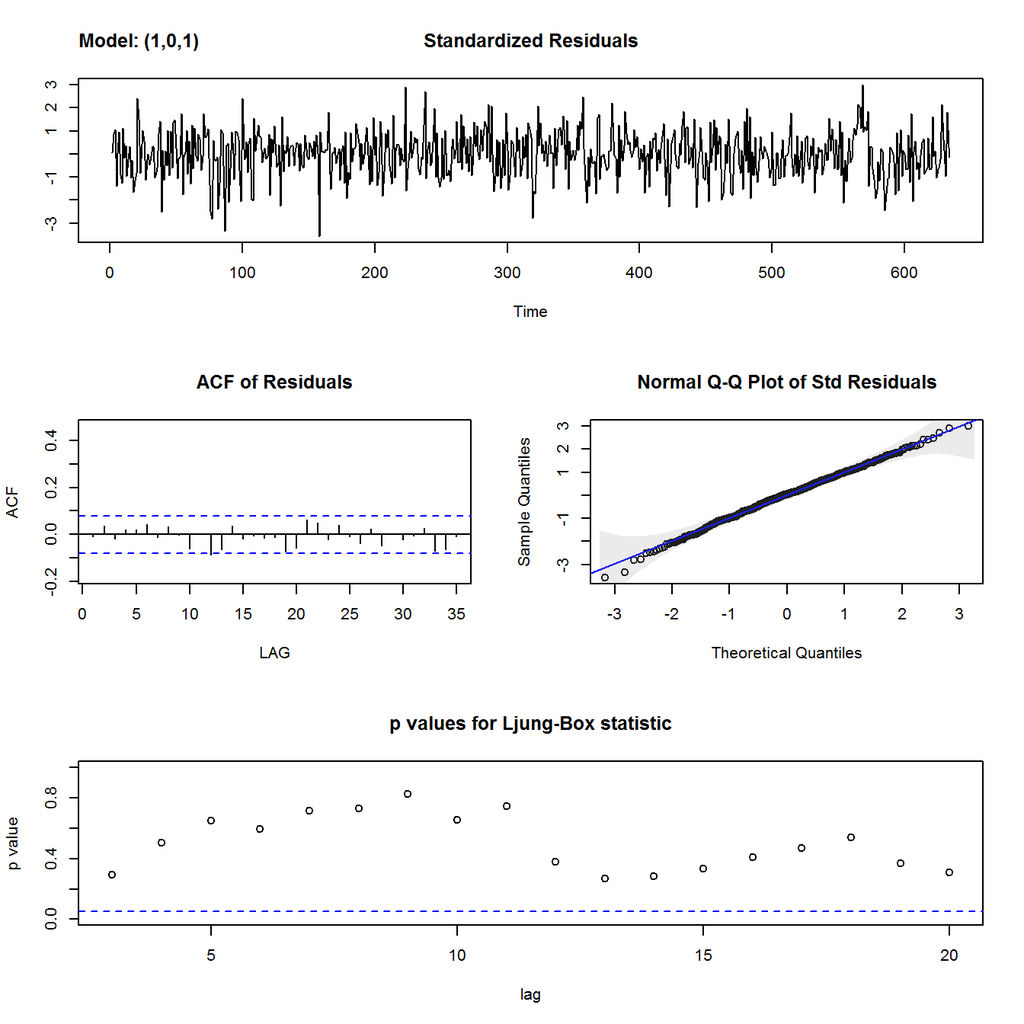

```
$fit

Call:
stats::arima(x = xdata, order = c(p, d, q), seasonal = list(order = c(P, D,
    Q), period = S), xreg = xmean, include.mean = FALSE, optim.control = list(trace = trc,
    REPORT = 1, reltol = tol))

Coefficients:
         ar1      ma1    xmean
      0.2341  -0.8871  -0.0013
s.e.  0.0518   0.0292   0.0028

sigma^2 estimated as 0.2284:  log likelihood = -431.33,  aic = 870.66

$degrees_of_freedom
[1] 630

$ttable
      Estimate     SE  t.value p.value
ar1     0.2341 0.0518   4.5184  0.0000
ma1    -0.8871 0.0292 -30.4107  0.0000
xmean  -0.0013 0.0028  -0.4618  0.6444

$AIC
[1] -0.467376

$AICc
[1] -0.4641159

$BIC
[1] -1.446284
```

```r
sarima(dl_varve,1,0,1)
```

**Residual Analysis:**

1. The standardized residuals should behave as a white noise sequence with mean zero and variance one. Examine the residual plot for departures from this behavior.

   As in the previous case, it’s hard to say. It seems not so white.
2. The sample ACF of the residuals should look like that of white noise. Examine the ACF for departures from this behavior.

   All values are inside the range, possibly white noise.
3. Normality is an essential assumption when fitting ARMA models. Examine the Q-Q plot for departures from normality and to identify outliers.

   As in the previous case, there’s reasonable normality with few outliers.
4. Use the Q-statistic plot to help test for departures from whiteness of the residuals.

   All p-values are above the limit, confirming there’s no correlation in the residuals and this is a good model fit.

## 12.4 Fitting a model to Crude oil, WTI spot price FOB

### 12.4.1 Calculate approximate oil returns

```r
data(oil)
oil_returns <- diff(log(oil))
```

### 12.4.2 Plot oil_returns.

Notice that there are a couple of outliers prior to 2004. Convince yourself that the returns are stationary.

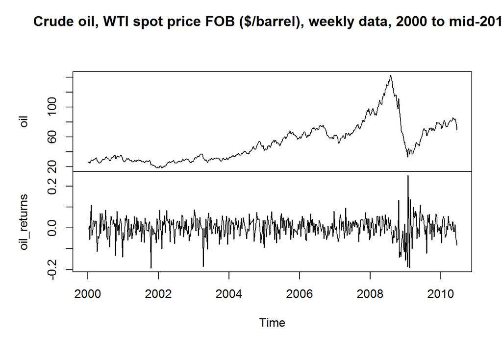

```r
plot(cbind(oil, oil_returns), main="Crude oil, WTI spot price FOB ($/barrel), weekly data, 2000 to mid-2010")
```

### 12.4.3 Plot the P/ACF pair for oil_returns

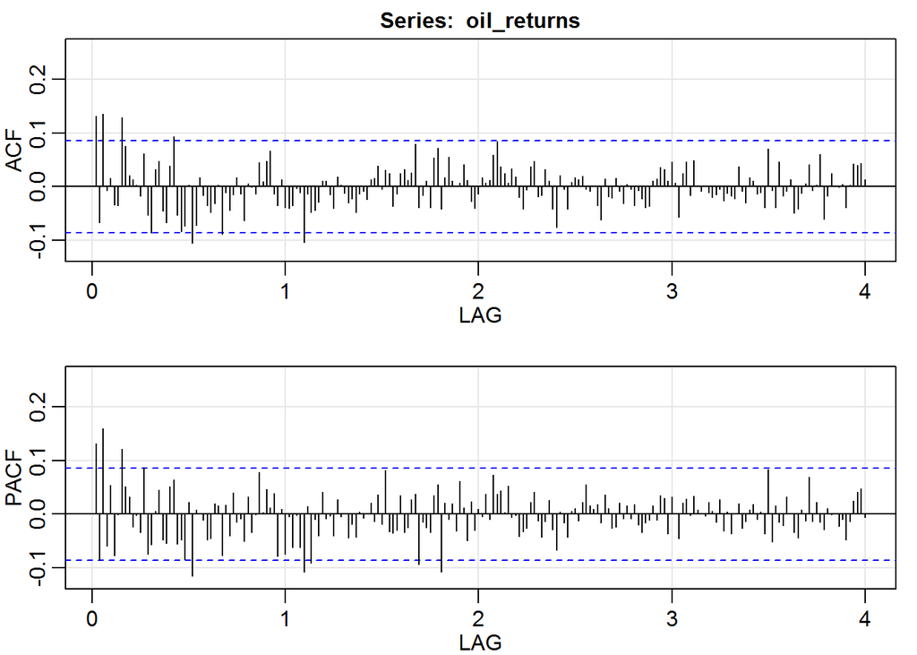

```
         ACF  PACF
  [1,]  0.13  0.13
  [2,] -0.07 -0.09
  [3,]  0.13  0.16
  [4,] -0.01 -0.06
  [5,]  0.02  0.05
  [6,] -0.03 -0.08
  [7,] -0.03  0.00
  [8,]  0.13  0.12
  [9,]  0.08  0.05
 [10,]  0.02  0.03
 [11,]  0.01 -0.02
 [12,]  0.00  0.00
 [13,] -0.02 -0.03
 [14,]  0.06  0.09
```

[output cut: 194 more lines]

```r
acf2(oil_returns)
```

### 12.4.4 Fit a model to oil_returns

From the P/ACF pair, it is apparent that the correlations are small and the returns are nearly noise. But it could be that both the ACF and PACF are tailing off. If this is the case, then an ARMA(1,1) is suggested. Fit this model to the oil returns using sarima().

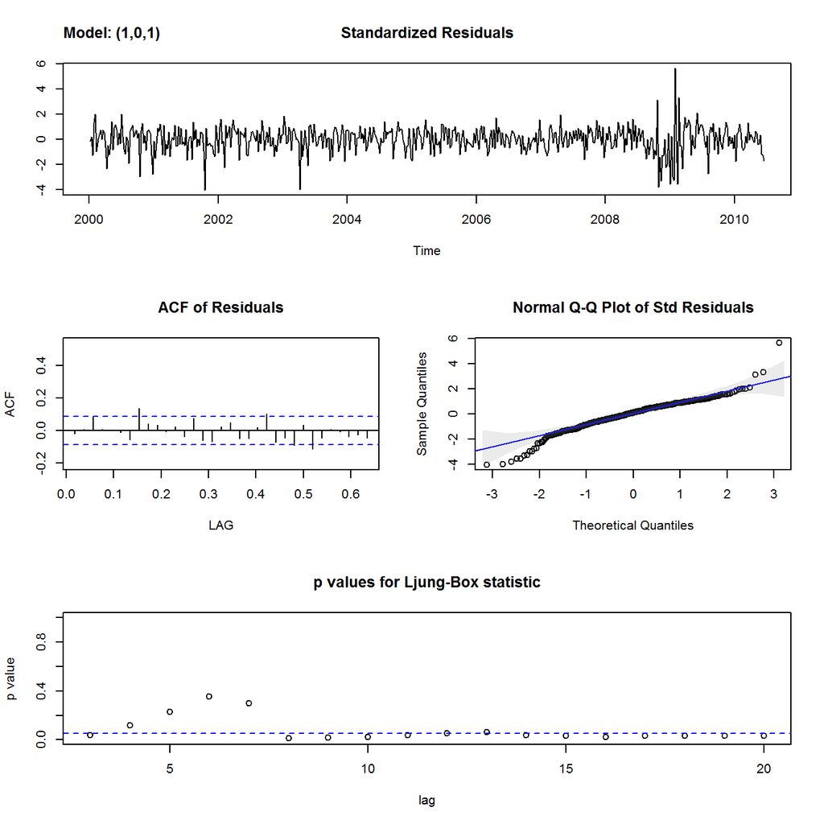

```
$fit

Call:
stats::arima(x = xdata, order = c(p, d, q), seasonal = list(order = c(P, D,
    Q), period = S), xreg = xmean, include.mean = FALSE, optim.control = list(trace = trc,
    REPORT = 1, reltol = tol))

Coefficients:
          ar1     ma1   xmean
      -0.5264  0.7146  0.0018
s.e.   0.0871  0.0683  0.0022

sigma^2 estimated as 0.002102:  log likelihood = 904.89,  aic = -1801.79

$degrees_of_freedom
[1] 541

$ttable
      Estimate     SE t.value p.value
ar1    -0.5264 0.0871 -6.0422  0.0000
ma1     0.7146 0.0683 10.4699  0.0000
xmean   0.0018 0.0022  0.7981  0.4252

$AIC
[1] -5.153838

$AICc
[1] -5.150025

$BIC
[1] -6.130131
```

```r
sarima(oil_returns, 1,0,1)
```

It seems not a good fit because most of the p-values are bellow the limit.

# 13 ARIMA - Integrated ARMA

A time series is called ARIMA(p,d,q) if the differenced series (of order d) is ARMA(p,q).

## 13.1 Identifying ARIMA

A time series exhibits ARIMA behavior if the differenced data has ARMA behavior.

Simulation ARIMA(p = 1, d = 1, q = 0)

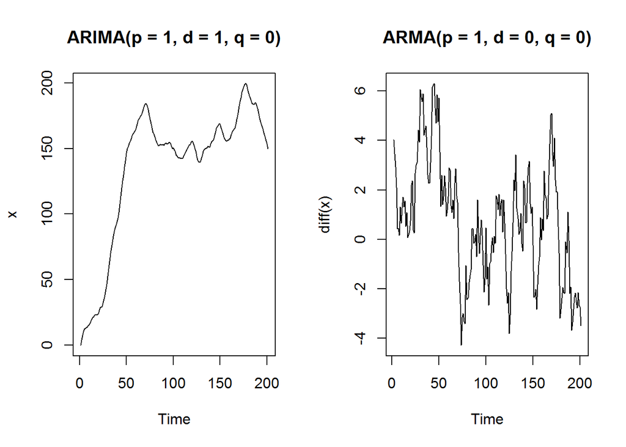

```r
x <- arima.sim(list(order = c(1, 1, 0), ar = .9), n = 200)
par(mfrow=1:2)
plot(x, main = "ARIMA(p = 1, d = 1, q = 0)")
plot(diff(x), main = "ARMA(p = 1, d = 0, q = 0)")
```

## 13.2 ACF and PACF of an Integrated ARMA

ACF decays in a linear fashion and PCF is almost 1 at lag one.

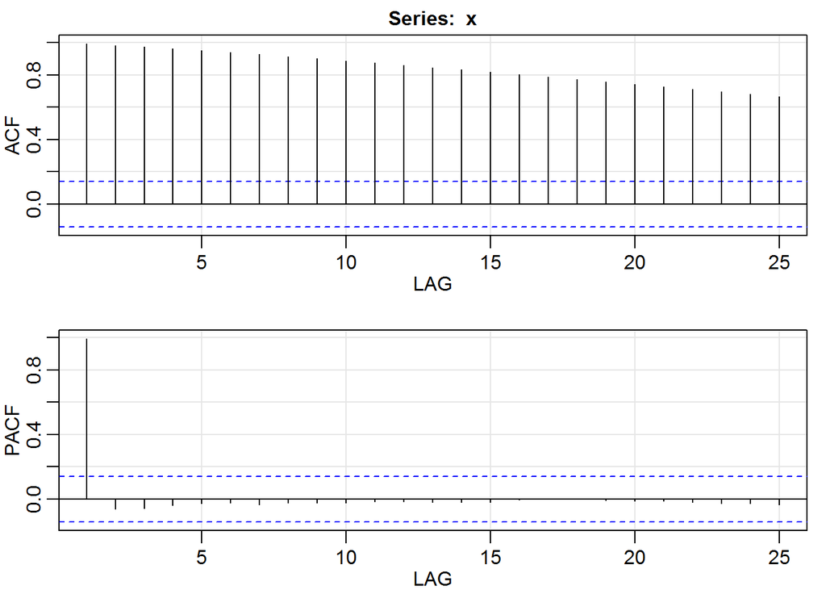

```
       ACF  PACF
 [1,] 0.99  0.99
 [2,] 0.98 -0.06
 [3,] 0.97 -0.06
 [4,] 0.96 -0.04
 [5,] 0.95 -0.03
 [6,] 0.94 -0.03
 [7,] 0.93 -0.03
 [8,] 0.91 -0.02
 [9,] 0.90 -0.03
[10,] 0.89 -0.02
[11,] 0.87 -0.01
[12,] 0.86 -0.01
[13,] 0.85 -0.02
[14,] 0.83 -0.02
[15,] 0.82 -0.02
[16,] 0.80 -0.01
[17,] 0.79  0.00
[18,] 0.77  0.00
[19,] 0.76 -0.01
[20,] 0.74 -0.01
[21,] 0.73 -0.01
[22,] 0.71 -0.02
[23,] 0.70 -0.03
[24,] 0.68 -0.03
[25,] 0.67 -0.03
```

```r
x <- arima.sim(list(order = c(1, 1, 0), ar = .9), n = 200)
acf2(x)
```

## 13.3 ACF and PACF of a differenced ARMA

Indicates and ARMA model for the differenced data: ACF tails off, PACF cutsoff at lag one.

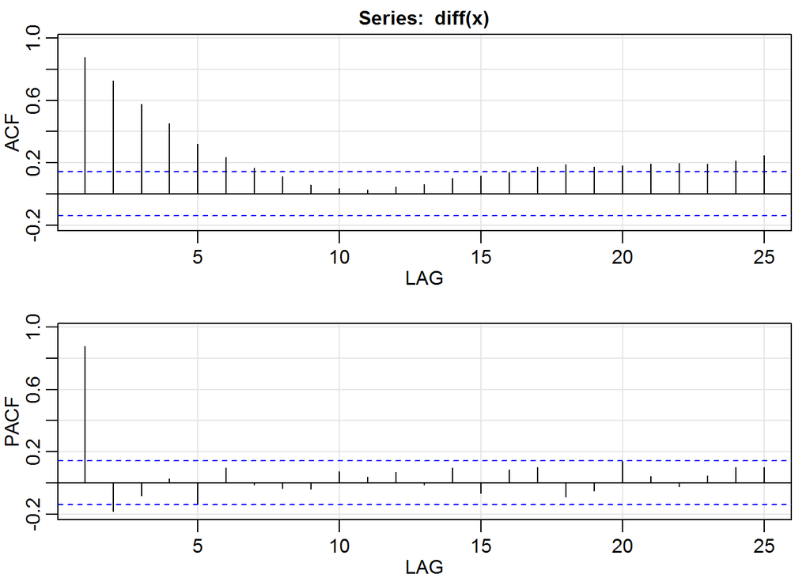

```
       ACF  PACF
 [1,] 0.88  0.88
 [2,] 0.73 -0.18
 [3,] 0.57 -0.08
 [4,] 0.45  0.03
 [5,] 0.32 -0.13
 [6,] 0.23  0.09
 [7,] 0.17 -0.01
 [8,] 0.11 -0.04
 [9,] 0.06 -0.04
[10,] 0.03  0.07
[11,] 0.03  0.04
[12,] 0.05  0.07
[13,] 0.06 -0.01
[14,] 0.10  0.10
[15,] 0.12 -0.07
[16,] 0.14  0.08
[17,] 0.17  0.10
[18,] 0.19 -0.09
[19,] 0.17 -0.05
[20,] 0.18  0.14
[21,] 0.19  0.04
[22,] 0.20 -0.02
[23,] 0.19  0.05
[24,] 0.21  0.10
[25,] 0.25  0.10
```

```r
x <- arima.sim(list(order = c(1, 1, 0), ar = .9), n = 200)
acf2(diff(x))
```

## 13.4 Weekly Oil Prices

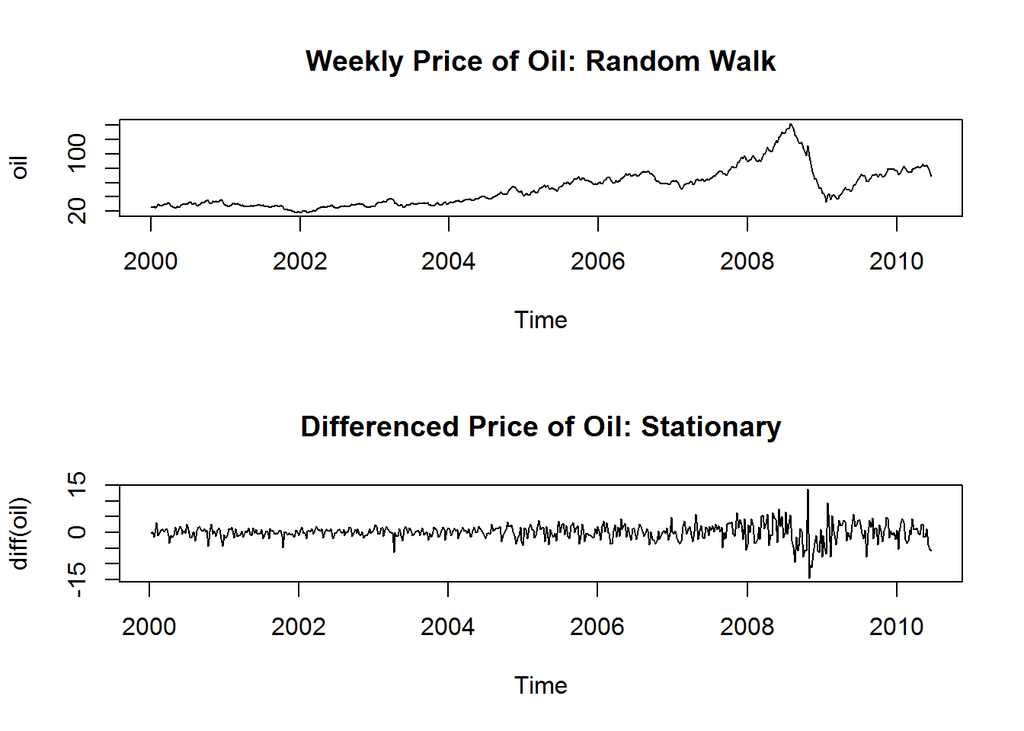

```r
par(mfrow=2:1)
plot(oil, main="Weekly Price of Oil: Random Walk")
plot(diff(oil), main="Differenced Price of Oil: Stationary")
```

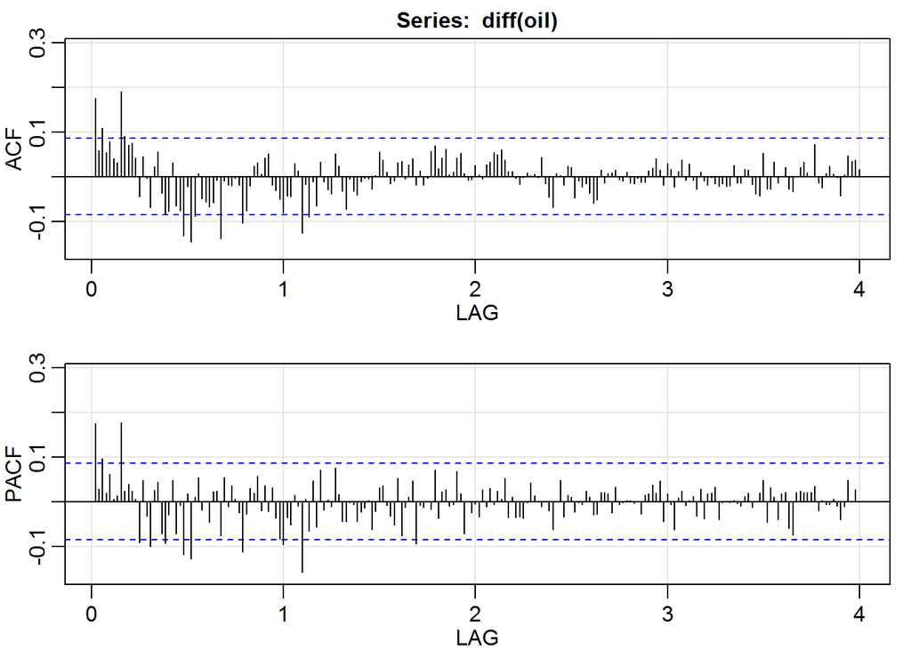

```r
invisible(acf2(diff(oil)))
```

Both ACF and PACF tail off, suggesting an ARMA(1,1) model on the differenced data or an ARIMA(1,1,1) on the data itself.

## 13.5 ARIMA - Plug and Play

Simulated data from the integrated model
$$Y_t=.9Y_t−1+W_t$$
where $Y_t=\nabla X_t=X_t−X_{t−1}$. In this case, the model is an ARIMA(1,1,0) because the differenced data are an autoregression of order one.

Plot x

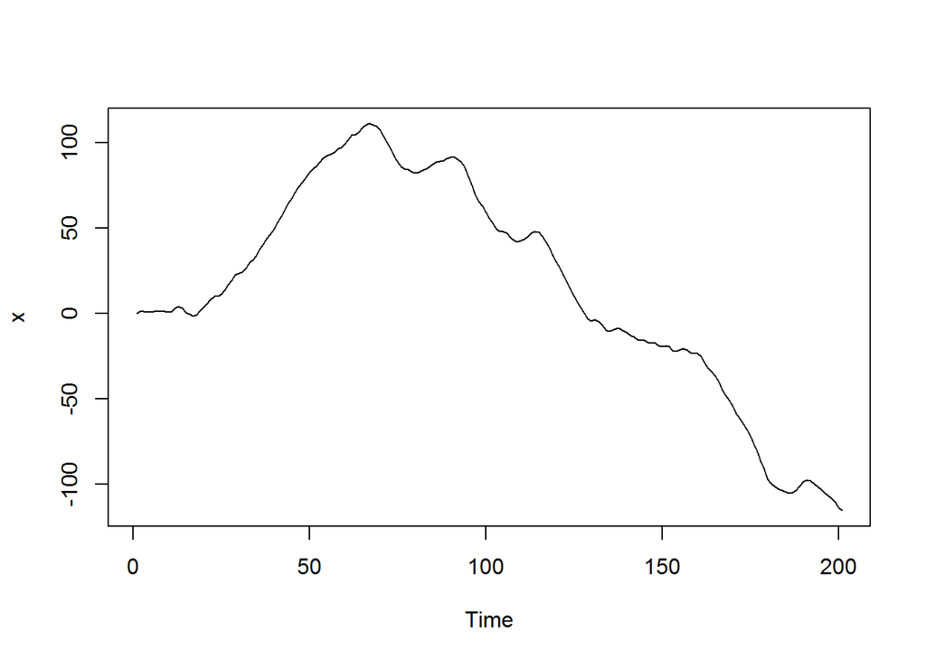

```r
x <- arima.sim(model = list(order = c(1, 1, 0), ar = .9), n = 200)
plot(x)
```

Plot the P/ACF pair of x

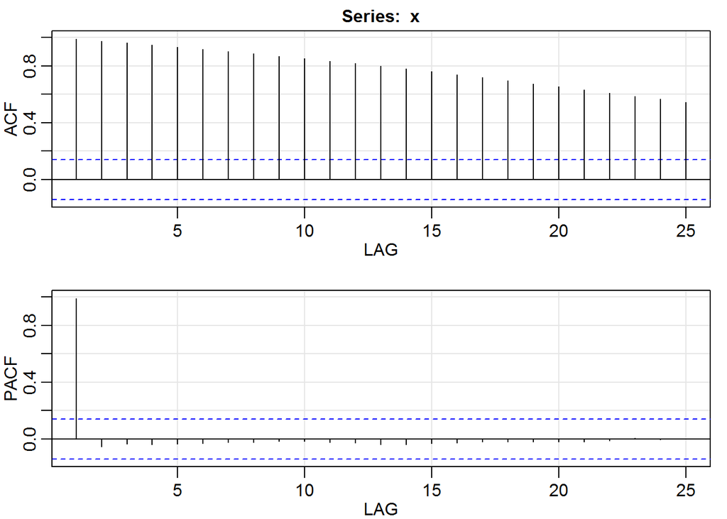

```
       ACF  PACF
 [1,] 0.99  0.99
 [2,] 0.98 -0.05
 [3,] 0.96 -0.03
 [4,] 0.95 -0.04
 [5,] 0.93 -0.03
 [6,] 0.92 -0.03
 [7,] 0.90 -0.03
 [8,] 0.89 -0.02
 [9,] 0.87 -0.02
[10,] 0.85 -0.02
[11,] 0.83 -0.02
[12,] 0.82 -0.03
[13,] 0.80 -0.04
[14,] 0.78 -0.04
[15,] 0.76 -0.03
[16,] 0.74 -0.03
[17,] 0.72 -0.02
[18,] 0.70 -0.02
[19,] 0.67 -0.02
[20,] 0.65 -0.02
[21,] 0.63 -0.02
[22,] 0.61 -0.01
[23,] 0.59  0.01
[24,] 0.57  0.00
[25,] 0.54  0.00
```

```r
acf2(x)
```

Plot the differenced data

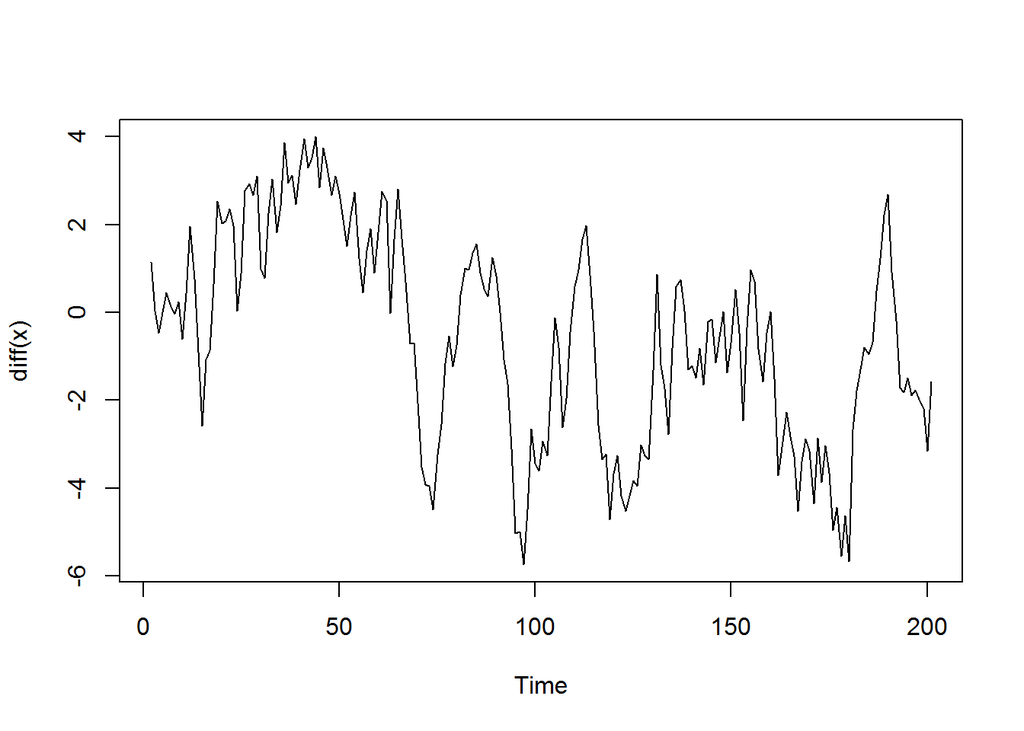

```r
plot(diff(x))
```

Plot the P/ACF pair of the differenced data

Note how they imply an AR(1) model for the differenced data. ACF tails off and PACF cuts off.

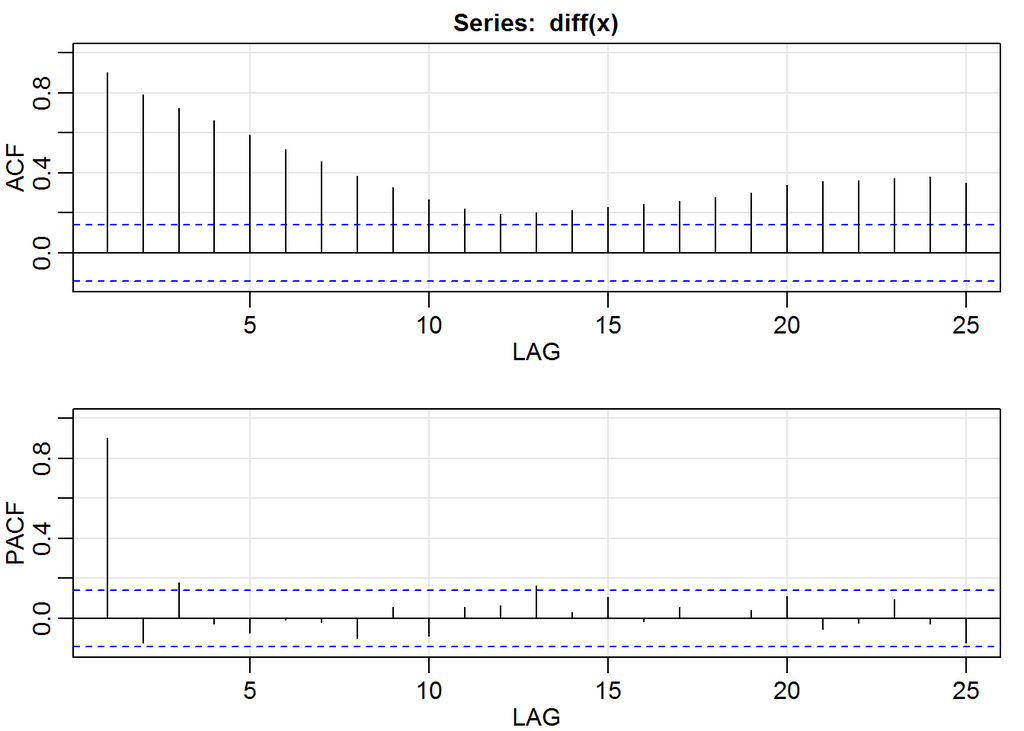

```
       ACF  PACF
 [1,] 0.90  0.90
 [2,] 0.79 -0.12
 [3,] 0.72  0.18
 [4,] 0.66 -0.03
 [5,] 0.59 -0.07
 [6,] 0.52 -0.01
 [7,] 0.46 -0.02
 [8,] 0.38 -0.10
 [9,] 0.32  0.06
[10,] 0.27 -0.09
[11,] 0.22  0.06
[12,] 0.19  0.07
[13,] 0.20  0.16
[14,] 0.21  0.03
[15,] 0.23  0.10
[16,] 0.24 -0.02
[17,] 0.26  0.06
[18,] 0.28  0.00
[19,] 0.30  0.04
[20,] 0.34  0.11
[21,] 0.36 -0.05
[22,] 0.36 -0.03
[23,] 0.37  0.09
[24,] 0.38 -0.03
[25,] 0.35 -0.12
```

```r
acf2(diff(x))
```

Differencing the data in your ARIMA(1,1,0) model makes it stationary and allows for further analysis